# IE48B- Homework 3

## Fish Dataset

- A set of Fish outlines originally used with contour matching in the paper "Contour Matching for Fish Species Recognition and Migration Monitoring" by D. Lee. Each class is a different species. Outlines were derived at UCR.

```python
fish_train = pd.read_csv("Fish_TRAIN.txt",sep=' ', header=None, skipinitialspace = True)
fish_test = pd.read_csv("Fish_TEST.txt", sep=' ', header=None, skipinitialspace = True)
train_classes = fish_train[0]
test_classes = fish_test[0]
fish_train.pop(0)
fish_test.pop(0)
fish_train.head()
```

|  | 1 | 2 | 3 | 4 | 5 | 6 | 7 | 8 | 9 | 10 | 11 | 12 | 13 | 14 | 15 | 16 | 17 | 18 | 19 | 20 | 21 | 22 | 23 | 24 | 25 | 26 | 27 | 28 | 29 | … |
| --- | --- | --- | --- | --- | --- | --- | --- | --- | --- | --- | --- | --- | --- | --- | --- | --- | --- | --- | --- | --- | --- | --- | --- | --- | --- | --- | --- | --- | --- | --- |
| 0 | 1.950905 | 1.926654 | 1.895665 | 1.858015 | 1.820566 | 1.790278 | 1.767617 | 1.731273 | 1.695241 | 1.658904 | 1.622969 | 1.586888 | 1.557218 | 1.521723 | 1.486103 | 1.450451 | 1.414024 | 1.377698 | 1.341477 | 1.305365 | 1.269866 | 1.234773 | 1.198903 | 1.163301 | 1.126734 | 1.092243 | 1.056584 | 1.021037 | 0.985608 | … |
| 1 | 1.966652 | 1.940113 | 1.915149 | 1.945426 | 1.959289 | 1.945119 | 1.919668 | 1.881009 | 1.856474 | 1.818359 | 1.780485 | 1.742000 | 1.703821 | 1.666606 | 1.628375 | 1.591032 | 1.552923 | 1.516177 | 1.478176 | 1.439941 | 1.404144 | 1.366323 | 1.330969 | 1.293702 | 1.258603 | 1.221986 | 1.184996 | 1.150198 | 1.114630 | … |
| 2 | 2.005598 | 1.994541 | 1.987894 | 1.970090 | 1.939982 | 1.903903 | 1.864944 | 1.826148 | 1.787538 | 1.749095 | 1.710781 | 1.672604 | 1.634694 | 1.596742 | 1.558857 | 1.520917 | 1.483069 | 1.445042 | 1.407299 | 1.369377 | 1.331597 | 1.294070 | 1.256724 | 1.219145 | 1.181652 | 1.144629 | 1.107333 | 1.070451 | 1.033465 | … |
| 3 | 1.878433 | 1.871449 | 1.844617 | 1.811412 | 1.777580 | 1.742792 | 1.709533 | 1.677253 | 1.643310 | 1.609233 | 1.577888 | 1.545911 | 1.512447 | 1.480485 | 1.450047 | 1.417959 | 1.385202 | 1.352954 | 1.320761 | 1.288783 | 1.257024 | 1.225491 | 1.194190 | 1.162516 | 1.129126 | 1.095784 | 1.065351 | 1.035180 | 1.005281 | … |
| 4 | 1.987342 | 1.968160 | 1.942338 | 1.909628 | 1.872595 | 1.843493 | 1.810693 | 1.774459 | 1.738029 | 1.703180 | 1.671636 | 1.636475 | 1.597700 | 1.559087 | 1.520641 | 1.482239 | 1.443966 | 1.405819 | 1.367822 | 1.329960 | 1.292246 | 1.254561 | 1.217038 | 1.179659 | 1.142261 | 1.105303 | 1.068523 | 1.031681 | 0.995067 | … |

```python
fish_test.shape
```

```
(175, 463)
```

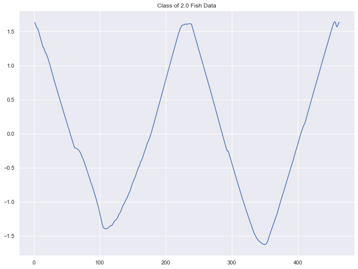

```python
sns.lineplot(y = fish_train.iloc[31].values, x = fish_train.iloc[78].index);
plt.title(f"Class of {train_classes[31]} Fish Data")
plt.show();
```

```python
performance,cv = pipeline(fish_train,fish_test,train_classes,test_classes)
```

```
Best K for Raw-Euclidean: 5  | Score: 0.7753594771241831

    Model : '5-NN with Euclidiean Distance'

    Confusion matrix :
    0   1   2   3   4   5   6
0  13   1   6   0   0   3   1
1   1  21   2   1   0   0   0
2   1   0  18   1   0   1   1
3   2   0   1  21   0   3   2
4   0   0   6   1  21   0   0
5   6   0   2   2   0  14   1
6   1   0   2   0   0   1  18


    Accuracy : 0.72



Best K for Raw-DTW: 1  | Score: 0.7337908496732025

    Model : '1-NN with DTW Distance'

    Confusion matrix :
    0  1   2  3  4   5  6
0   8  0   7  0  0   9  0
1   9  0   6  0  0  10  0
2   6  0   5  0  0  11  0
3   7  0  15  0  0   7  0
4  16  0  11  0  0   1  0
5  16  0   5  0  0   4  0
6  17  0   5  0  0   0  0


    Accuracy : 0.09714285714285714



Best K for Raw-Manhattan: 3  | Score: 0.7566666666666664

```

[output cut: 176 more lines]

```

    Model : '5-NN with SAX-Minkowski Distance'

    Confusion matrix :
   0   1   2   3  4  5  6
0  2   5   6   5  0  3  3
1  0   9   0   2  3  2  9
2  1   1  15   2  0  1  2
3  6   9   1   9  0  0  4
4  2  13   3   1  5  1  3
5  1   4   1  11  0  4  4
6  6   3   2   7  0  0  4


    Accuracy : 0.2742857142857143
```

```python
performance
```

```
[['Euclidean | Raw ', 0.72],
 ['Raw | DTW ', 0.09714285714285714],
 ['Manhattan | Raw ', 0.7542857142857143],
 ['Minkowski | Raw ', 0.7942857142857143],
 ['Euclidean | PCA ', 0.42857142857142855],
 ['DTW | PCA ', 0.13142857142857142],
 ['Manhattan | PCA ', 0.42857142857142855],
 ['Minkowski | PCA ', 0.49142857142857144],
 ['Euclidean | SAX ', 0.44],
 ['DTW | SAX ', 0.13142857142857142],
 ['Manhattan | SAX ', 0.5714285714285714],
 ['Minkowski | SAX ', 0.2742857142857143]]
```

```python
cv
```

```
[['Best K for Raw-Euclidean:', 5, ' | Score:', 0.7753594771241831],
 ['Best K for Raw-DTW:', 1, ' | Score:', 0.7337908496732025],
 ['Best K for Raw-Manhattan:', 3, ' | Score:', 0.7566666666666664],
 ['Best K for Raw-Minkowski:', 1, ' | Score:', 0.746732026143791],
 ['Best K for PCA-Euclidean:', 1, ' | Score:', 0.6167973856209151],
 ['Best K for PCA-DTW:', 3, ' | Score:', 0.6056862745098041],
 ['Best K for PCA-Manhattan:', 3, ' | Score:', 0.6082352941176471],
 ['Best K for PCA-Minkowski:', 5, ' | Score:', 0.6009803921568628],
 ['Best K for SAX-Euclidean:', 1, ' | Score:', 0.6889542483660133],
 ['Best K for SAX-DTW:', 1, ' | Score:', 0.14437908496732027],
 ['Best K for SAX-Manhattan:', 5, ' | Score:', 0.6814379084967319],
 ['Best K for SAX-Minkowski:', 5, ' | Score:', 0.3502614379084968]]
```

## ECG Dataset

- This dataset was formatted by R. Olszewski as part of his thesis "Generalized feature extraction for structural pattern recognition in time-series data" at Carnegie Mellon University, 2001. Each series traces the electrical activity recorded during one heartbeat. The two classes are a normal heartbeat and a Myocardial Infarction.

```python
ecg_train = pd.read_csv("ECG200_TRAIN.txt",sep=' ', header=None, skipinitialspace = True)
ecg_test = pd.read_csv("ECG200_TEST.txt", sep=' ', header=None, skipinitialspace = True)
train_classes = ecg_train[0]
test_classes = ecg_test[0]
ecg_train.pop(0)
ecg_test.pop(0)
ecg_train.head()
```

|  | 1 | 2 | 3 | 4 | 5 | 6 | 7 | 8 | 9 | 10 | 11 | 12 | 13 | 14 | 15 | 16 | 17 | 18 | 19 | 20 | 21 | 22 | 23 | 24 | 25 | 26 | 27 | 28 | 29 | … |
| --- | --- | --- | --- | --- | --- | --- | --- | --- | --- | --- | --- | --- | --- | --- | --- | --- | --- | --- | --- | --- | --- | --- | --- | --- | --- | --- | --- | --- | --- | --- |
| 0 | 0.502055 | 0.542163 | 0.722383 | 1.428885 | 2.136516 | 2.281149 | 1.936274 | 1.468890 | 1.008845 | 0.380282 | -0.296780 | -0.513929 | -0.255645 | -0.107203 | -0.287827 | -0.418009 | -0.319163 | -0.260379 | -0.350357 | -0.505486 | -0.710887 | -0.823920 | -0.899702 | -1.153950 | -1.229831 | -1.044091 | -1.202031 | -1.392195 | -1.130108 | … |
| 1 | 0.147647 | 0.804668 | 0.367771 | 0.243894 | 0.026614 | -0.274402 | 0.096731 | -0.747731 | -1.609777 | -1.179593 | -1.055926 | -1.128777 | -0.686039 | -0.798789 | -1.714279 | -1.649858 | -1.032699 | -1.423918 | -1.782433 | -1.025126 | -1.798909 | -1.793614 | -1.085478 | -1.574390 | -1.036059 | -2.130021 | -2.038621 | -0.055013 | -1.140195 | … |
| 2 | 0.316646 | 0.243199 | 0.370471 | 1.063738 | 1.678187 | 1.759558 | 1.697717 | 1.612159 | 1.168188 | 0.499957 | -0.022363 | -0.235318 | -0.118273 | -0.071027 | -0.322986 | -0.433562 | -0.318660 | -0.295655 | -0.417733 | -0.682480 | -0.881840 | -0.843320 | -0.883652 | -1.030018 | -1.055265 | -1.168637 | -1.363991 | -1.337611 | -1.261294 | … |
| 3 | 1.168874 | 2.075901 | 1.760141 | 1.606446 | 1.949046 | 1.302842 | 0.459332 | 0.516412 | 0.852180 | 0.989227 | 0.821253 | 0.576448 | 0.743089 | 0.852970 | 0.307458 | -0.130391 | -0.062200 | -0.100727 | -0.232818 | -0.234465 | -0.214756 | -0.230413 | -0.227551 | -0.231002 | -0.463479 | -0.724215 | -0.787885 | -0.986687 | -1.224672 | … |
| 4 | 0.648658 | 0.752026 | 2.636231 | 3.455716 | 2.118157 | 0.520620 | -0.188627 | 0.780818 | 0.933775 | 0.701402 | 1.006133 | 0.395784 | -0.369703 | -0.738202 | -0.729084 | -0.906940 | -0.870962 | -1.060217 | -1.197958 | -0.981602 | -1.272497 | -1.287380 | -1.276698 | -1.539702 | -1.346610 | -1.535217 | -1.763418 | -1.688821 | -1.809368 | … |

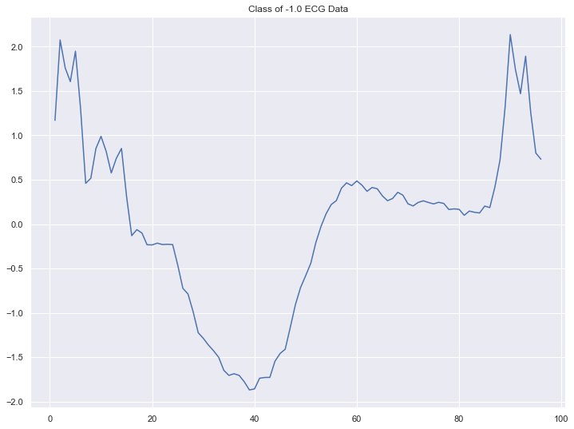

```python
sns.lineplot(y = ecg_train.iloc[3].values, x = ecg_train.iloc[3].index);
plt.title(f"Class of {train_classes[3]} ECG Data")
plt.show();
```

```python
performance,cv = pipeline(ecg_train,ecg_test,train_classes,test_classes)
```

```
Best K for Raw-Euclidean: 3  | Score: 0.894

    Model : '3-NN with Euclidiean Distance'

    Confusion matrix :
    0   1
0  29   7
1   3  61


    Accuracy : 0.9



Best K for Raw-DTW: 5  | Score: 0.8100000000000003

    Model : '5-NN with DTW Distance'

    Confusion matrix :
    0   1
0  13  23
1  17  47


    Accuracy : 0.6



Best K for Raw-Manhattan: 1  | Score: 0.848

    Model : '1-NN with Manhattan Distance'

    Confusion matrix :
    0   1
0  29   7
1   4  60


    Accuracy : 0.89

```

[output cut: 116 more lines]

```



Best Bin Value Number: 4  | Score: 0.7919999999999999
Best K for SAX-Minkowski 5  | Score: 0.7919999999999999

    Model : '5-NN with SAX-Minkowski Distance'

    Confusion matrix :
    0   1
0  27   9
1   7  57


    Accuracy : 0.84
```

```python
performance
```

```
[['Euclidean | Raw ', 0.9],
 ['Raw | DTW ', 0.6],
 ['Manhattan | Raw ', 0.89],
 ['Minkowski | Raw ', 0.85],
 ['Euclidean | PCA ', 0.77],
 ['DTW | PCA ', 0.57],
 ['Manhattan | PCA ', 0.76],
 ['Minkowski | PCA ', 0.67],
 ['Euclidean | SAX ', 0.78],
 ['DTW | SAX ', 0.51],
 ['Manhattan | SAX ', 0.78],
 ['Minkowski | SAX ', 0.84]]
```

```python
cv
```

```
[['Best K for Raw-Euclidean:', 3, ' | Score:', 0.894],
 ['Best K for Raw-DTW:', 5, ' | Score:', 0.8100000000000003],
 ['Best K for Raw-Manhattan:', 1, ' | Score:', 0.848],
 ['Best K for Raw-Minkowski:', 3, ' | Score:', 0.87],
 ['Best K for PCA-Euclidean:', 1, ' | Score:', 0.8819999999999999],
 ['Best K for PCA-DTW:', 3, ' | Score:', 0.8480000000000001],
 ['Best K for PCA-Manhattan:', 1, ' | Score:', 0.8540000000000001],
 ['Best K for PCA-Minkowski:', 1, ' | Score:', 0.852],
 ['Best K for SAX-Euclidean:', 1, ' | Score:', 0.8460000000000001],
 ['Best K for SAX-DTW:', 1, ' | Score:', 0.7120000000000001],
 ['Best K for SAX-Manhattan:', 1, ' | Score:', 0.8440000000000001],
 ['Best K for SAX-Minkowski:', 5, ' | Score:', 0.7919999999999999]]
```

## Large Kitchen Appliances Dataset

```python
lka_train = pd.read_csv("LargeKitchenAppliances_TRAIN.txt",sep=' ', header=None, skipinitialspace = True)
lka_test = pd.read_csv("LargeKitchenAppliances_TEST.txt", sep=' ', header=None, skipinitialspace = True)
train_classes = lka_train[0]
test_classes = lka_test[0]
lka_train.pop(0)
lka_test.pop(0)
lka_train.head()
```

|  | 1 | 2 | 3 | 4 | 5 | 6 | 7 | 8 | 9 | 10 | 11 | 12 | 13 | 14 | 15 | 16 | 17 | 18 | 19 | 20 | 21 | 22 | 23 | 24 | 25 | 26 | 27 | 28 | 29 | … |
| --- | --- | --- | --- | --- | --- | --- | --- | --- | --- | --- | --- | --- | --- | --- | --- | --- | --- | --- | --- | --- | --- | --- | --- | --- | --- | --- | --- | --- | --- | --- |
| 0 | -0.099108 | -0.099108 | -0.099108 | -0.099108 | -0.099108 | -0.099108 | -0.099108 | -0.099108 | -0.099108 | -0.099108 | -0.099108 | -0.099108 | -0.099108 | -0.099108 | -0.099108 | -0.099108 | -0.099108 | -0.099108 | -0.099108 | -0.099108 | -0.099108 | -0.099108 | -0.099108 | -0.099108 | -0.099108 | -0.099108 | -0.099108 | -0.099108 | -0.099108 | … |
| 1 | -0.155256 | -0.155256 | -0.155256 | -0.155256 | -0.155256 | -0.155256 | -0.155256 | -0.155256 | -0.155256 | -0.155256 | -0.155256 | -0.155256 | -0.155256 | -0.155256 | -0.155256 | -0.155256 | -0.155256 | -0.155256 | -0.155256 | -0.155256 | -0.155256 | -0.155256 | -0.155256 | -0.155256 | -0.155256 | -0.155256 | -0.155256 | -0.155256 | -0.155256 | … |
| 2 | -0.100082 | -0.100082 | -0.100082 | -0.100082 | -0.100082 | -0.100082 | -0.100082 | -0.100082 | -0.100082 | -0.100082 | -0.100082 | -0.100082 | -0.100082 | -0.100082 | -0.100082 | -0.100082 | -0.100082 | -0.100082 | -0.100082 | -0.100082 | -0.100082 | -0.100082 | -0.100082 | -0.100082 | -0.100082 | -0.100082 | -0.100082 | -0.100082 | -0.100082 | … |
| 3 | -0.140671 | -0.140671 | -0.140671 | -0.140671 | -0.140671 | -0.140671 | -0.140671 | -0.140671 | -0.140671 | -0.140671 | -0.140671 | -0.140671 | -0.140671 | -0.140671 | -0.140671 | -0.140671 | -0.140671 | -0.140671 | -0.140671 | -0.140671 | -0.140671 | -0.140671 | -0.140671 | -0.140671 | -0.140671 | -0.140671 | -0.140671 | -0.140671 | -0.140671 | … |
| 4 | -0.140576 | -0.140576 | -0.140576 | -0.140576 | -0.140576 | -0.140576 | -0.140576 | -0.140576 | -0.140576 | -0.140576 | -0.140576 | -0.140576 | -0.140576 | -0.140576 | -0.140576 | -0.140576 | -0.140576 | -0.140576 | -0.140576 | -0.140576 | -0.140576 | -0.140576 | -0.140576 | -0.140576 | -0.140576 | -0.140576 | -0.140576 | -0.140576 | -0.140576 | … |

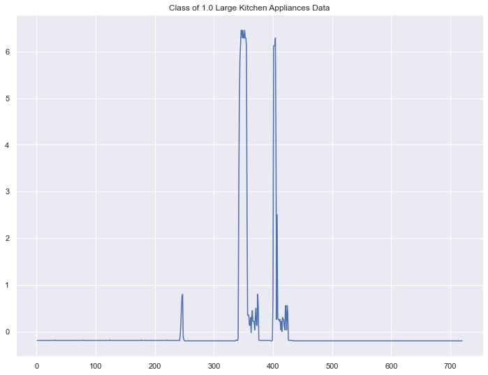

```python
sns.lineplot(y = lka_train.iloc[5].values, x = lka_train.iloc[3].index);
plt.title(f"Class of {train_classes[5]} Large Kitchen Appliances Data")
plt.show();
```

```python
performance,cv = pipeline(lka_train,lka_test,train_classes,test_classes)
```

```
Best K for Raw-Euclidean: 1  | Score: 0.6000284495021337

    Model : '1-NN with Euclidiean Distance'

    Confusion matrix :
    0   1   2
0  56  33  36
1  32  53  40
2  27  22  76


    Accuracy : 0.49333333333333335



Best K for Raw-DTW: 1  | Score: 0.8132432432432433

    Model : '1-NN with DTW Distance'

    Confusion matrix :
    0    1   2
0  24   91  10
1  16  108   1
2  13   90  22


    Accuracy : 0.4106666666666667



Best K for Raw-Manhattan: 1  | Score: 0.675135135135135

    Model : '1-NN with Manhattan Distance'

    Confusion matrix :
    0   1   2
0  68  26  31
1  28  66  31
2  24  26  75

```

[output cut: 128 more lines]

```


Best Bin Value Number: 5  | Score: 0.3727453769559033
Best K for SAX-Minkowski 5  | Score: 0.3727453769559033

    Model : '5-NN with SAX-Minkowski Distance'

    Confusion matrix :
     0   1  2
0  122   1  2
1  118   4  3
2  112  10  3


    Accuracy : 0.344
```

```python
performance
```

```
[['Euclidean | Raw ', 0.49333333333333335],
 ['Raw | DTW ', 0.4106666666666667],
 ['Manhattan | Raw ', 0.5573333333333333],
 ['Minkowski | Raw ', 0.424],
 ['Euclidean | PCA ', 0.4],
 ['DTW | PCA ', 0.6906666666666667],
 ['Manhattan | PCA ', 0.3973333333333333],
 ['Minkowski | PCA ', 0.3973333333333333],
 ['Euclidean | SAX ', 0.39466666666666667],
 ['DTW | SAX ', 0.7973333333333333],
 ['Manhattan | SAX ', 0.39466666666666667],
 ['Minkowski | SAX ', 0.344]]
```

```python
cv
```

```
[['Best K for Raw-Euclidean:', 1, ' | Score:', 0.6000284495021337],
 ['Best K for Raw-DTW:', 1, ' | Score:', 0.8132432432432433],
 ['Best K for Raw-Manhattan:', 1, ' | Score:', 0.675135135135135],
 ['Best K for Raw-Minkowski:', 3, ' | Score:', 0.4753342816500711],
 ['Best K for PCA-Euclidean:', 3, ' | Score:', 0.6172546230440967],
 ['Best K for PCA-DTW:', 3, ' | Score:', 0.6194310099573258],
 ['Best K for PCA-Manhattan:', 3, ' | Score:', 0.6145234708392604],
 ['Best K for PCA-Minkowski:', 3, ' | Score:', 0.6059174964438123],
 ['Best K for SAX-Euclidean:', 1, ' | Score:', 0.5492460881934567],
 ['Best K for SAX-DTW:', 5, ' | Score:', 0.38665718349928874],
 ['Best K for SAX-Manhattan:', 1, ' | Score:', 0.5872546230440968],
 ['Best K for SAX-Minkowski:', 5, ' | Score:', 0.3727453769559033]]
```